# Bayesian Meta-Analysis

Computational Modelling - Portfolio 4

Magnus Knudsen, Victor Møller, Anders Weile, Jan Kostkan, Carl-Magnus Christiansen

2019-05-10

# Quick overview

In this analysis, we will be implementing priors arising form meta-analyses into the Bayesian modeling framework. In order to illustrate what consequences the usage of different priors might have, we fit two models of pitch data: first one using custom weakly regularizing priors and the second one using meta-analytic priors. Said meta-analytic priors are acquired as the first step in this process: we conduct a Bayesian meta-analysis of provided studies.

# Preparing the analysis

The outcome variable of interest in this assignment is the standard deviation of pitch. This variable is not normally distributed, indicating that it arises from a non-additive process. It is instead log-normally distributed. Thus we decided to transform variables of interest both in the meta-analytic data and the data from Riccardo’s study of pitch.

In order to prepare the meta-analytic data, we have drawn from a transformation formula presented by [Quan & Zhang (2003)](https://onlinelibrary-wiley-com.ez.statsbiblioteket.dk:12048/doi/epdf/10.1002/sim.1525). That is, we went back to the meta-analysis and calculated variance for the standard deviation of pitch (separately for schizophrenics and controls). Next, this variance is log transformed in order to make the variable approximately normally distributed, as we are fitting a model of the Gaussian family. Finally, the square root of this transformed variable is taken, giving us the standard deviation of log transformed standard deviation of the pitch.

> `sqrt(log(SD of SD of pitch^2 / Mean of SD of pitch^2))`

Since variance is the square root of standard deviation we took the square root of the variance to obtain the logarithm of standard deviation. We then proceeded to calculate the logarithm of the mean & then used the `escalc`-function from the `metafor`-package to obtain effect size (yi) and* *variance of said effect sizes (vi).

For the data in Riccardo’s study we took the logarithm and then z-scored the outcome variable standard deviation of pitch.

This preprocessing ensures that the data from the meta-analysis and the data from Riccardo’s studies are comparable (which we need when we use the meta-analytic prior in task 4).

**Making the meta-analysis**

In constructing the meta-analysis we used Matti Vuorre’s [framework](https://vuorre.netlify.com/post/2016/09/29/meta-analysis-is-a-special-case-of-bayesian-multilevel-modeling/). The model estimates `effect size (yi)` and weighs it by `variance (vi)`. The studies which factor in to the meta-analysis are modeled as random effects. We chose to use the `studyref` column which treats each study as independent in our random effects structure. Another approach would have been to base it on author (I.e., assuming that the variation in results are due to experimenter/lab variation).

## Effect size with standard deviation of studies included in Meta Analysis (Forest Plot)

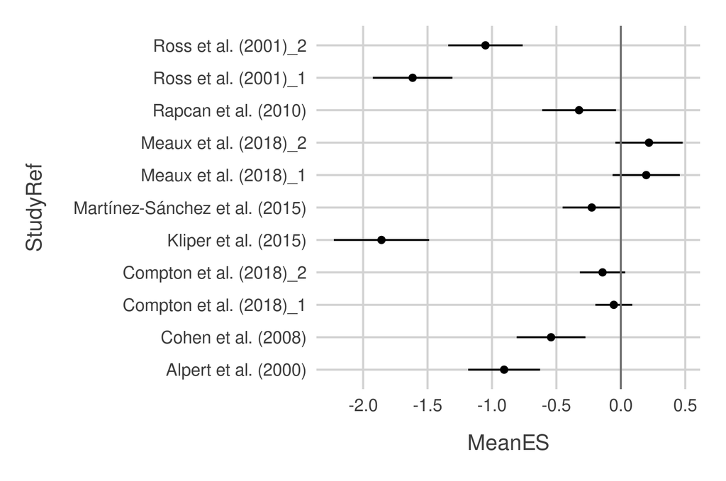

# Making the model (weakly regularizing priors)

**Random effects:**

We have identified hierarchy in our data to be used as random intercepts; These include unique participant ID, session number (data was collected across three sessions) and trial number. Using these levels we aim to capture non-systematic variance arising from differences between participants not caused by diagnosis and from circumstances at data collection. Each participant took part in only one session and completed up to 10 trials. Although instructions in each session differed slightly, they aimed to capture the same effect, which makes differences between said sessions unsystematic in the context of our analysis.

**Distribution of outcome**

As the outcome variable (standard deviation of pitch) was log-transformed, our model will estimate a normal distribution on a log-scale. This means that the outcome variable is exponentially distributed on a natural scale.

The intercept (which here is the estimate of controls) follows a normal distribution on the log-scale, which is also the case for the beta (effect of diagnosis). This indicates that both processes are exponential on the natural scale.

**Priors**

When setting priors, we went for weakly regularizing priors, considering the scale of the data and pushing the model towards a null result. Because the data is transformed twice, we first considered the priors on the natural sale before transforming them to the log-z-scale. Our priors for the intercept and error of the intercept were normal distributions with means of zero and standard deviations of 0.2. Our priors for the effect size (beta-estimate) and sigma were normal distributions with means of zero and standard deviations of 0.3.

## Plot showing the predicted posterior of diagnosis (violin) and the raw data (dots & boxplot).

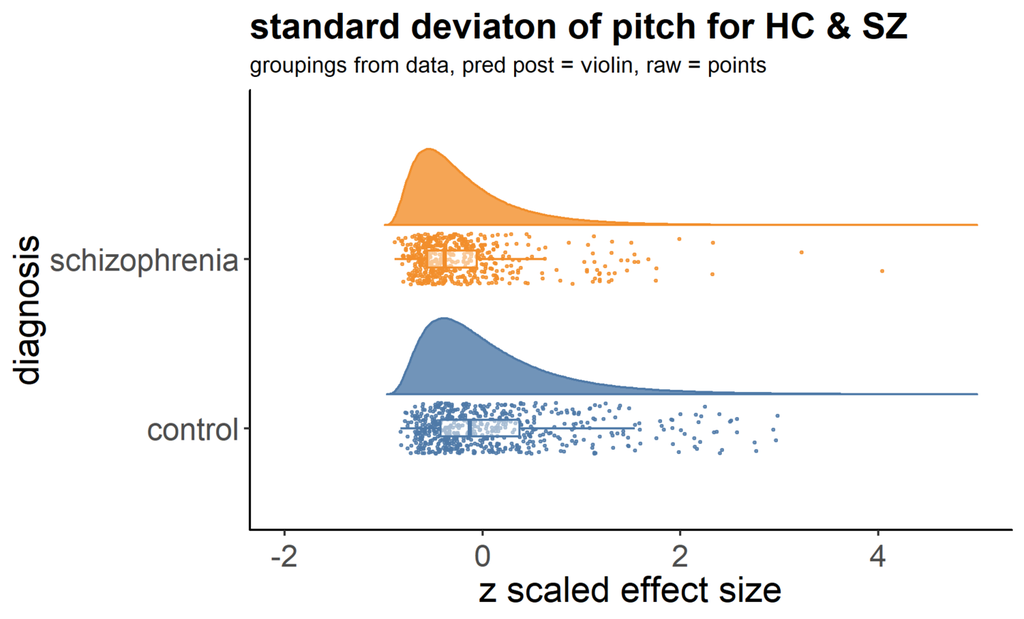

As can be seen the predictive posteriors for the two groups overlap strongly.

# Making the model (meta-analytic priors)

**Overview**

Our second model has the same random structure as the first one. The difference lies in the priors. While we kept the priors for the intercept, standard deviation, and sigma the same, the prior mean effect size was set to a normal distribution with a mean of -0.57 and a standard deviation of 0.25 which were the approximate effect size estimates obtained from the meta-analysis.

# Model comparison

**Estimates for weakly regularizing model**

|  | **Lower bound (99% HPDI)** | **Upper bound (99% HPDI)** |
| --- | --- | --- |
| diagnosis effect size | -0.28 | -0.14 |

The fitted estimates of the effect of diagnosis on pitch standard deviation are shown above for the model with a regularizing prior. The estimates are on a z-scale. The effect is reliably negative (with a 99% HPDI).

**Estimates for meta-model**

The estimates for the meta-model were:

|  | **Lower bound (99% HPDI)** | **Upper bound (99% HPDI)** |
| --- | --- | --- |
| diagnosis effect size | -0.29 | -0.15 |

As can be seen the estimates for the effect size and associated HDPIs are very similar in the two models. They both predict a consistent negative effect of diagnosis on pitch standard deviation. This happens even though the meta-analysis skews the posterior towards a ‘significant’ effect while the weakly-regularizing model skews the posterior beta towards null. Because we have a relatively large amount of data, it makes sense that both models are influenced primarily by the data (likelihood) and less by the priors. Thus we get similar estimates for the effect size from both models.

**Comparing the models**

## Plot comparing effect sizes

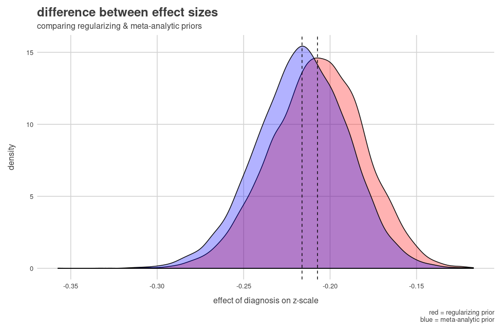

The plot shows the difference between the posteriors of the model using regularizing priors and the posterior from the model using the meta-analytic priors. The posteriors have a very similar shape, but the model with the meta-analytic prior is slightly shifted towards a more negative (a stronger) effect than the posterior of the model using the regularizing prior.

**WAIC**

In order to assess the value of using meta-analytic priors, we compare a model with meta-analytic priors to a model with weakly regularizing priors, using WAIC-scores as our measurement.

|  | WAIC | SE_WAIC |
| --- | --- | --- |
| Weakly-regularizing prior | 2849.5 | 86 |
| Meta-analytic prior | 2850.1 | 86.5 |

# Bayesian reflection

When doing Bayesian analyses, we set priors that reflect our state of knowledge before evaluating the data. Our prior knowledge may be very sparse as in the case when we use weakly regularizing priors. We might incorporate expert knowledge, or we might use results from a meta-analysis. In the hierarchy of evidence, meta-analyses are on top because they reflect the hitherto accumulation of scientific evidence at a given point in time. And in principle, estimates from a meta-analysis provide the most qualified guess at the true parameter value. Especially if you are conducting a study where having many participants is infeasible, you could benefit from meta-analytic priors.

However, there are some drawbacks to using meta-analytic priors. Conducting a meta-analysis takes time, and sometimes, as exemplified in our analysis, weakly regularizing priors will do almost just as well as meta-analytic priors. Furthermore, if the quality of the studies selected for meta-analysis is low, using a meta-analytic prior can be outright misleading. This is also true if the field as a whole is subject to publication biases (e.g. the file-drawer problem). On the other hand, having a strong meta-analytic priors can safeguard against publication bias by forcing the models to be skeptical of flashy results. Lastly, an obvious, but nonetheless important, condition for using meta-analytic priors is that the studies in the meta-analysis are actually measuring the same thing. If the conditions of the studies are very different, e.g. different experimental conditions, different measured parameters etc., a meta-analysis won’t be very illuminating.

In sum, using meta-analytic priors perfectly reflect the Bayesian philosophy: “Yesterday’s posterior is today’s prior.” They provide the strongest indication of the state of the field. Nevertheless, one should always be wary and carefully assess the quality of the studies used for the meta-analysis.